# 重賞レース予測レポート【毎時自動更新中】

作成日時: 2026/03/27 11:05:24

☞ [マニュアル(pdf)](https://ryutoro-galois.github.io/keiba-predictor/manual/manual.pdf)

☞ 過去6年の同一レース結果: [2025年](https://ryutoro-galois.github.io/keiba-predictor/report/PredResult_2025y_raceDate_20250329_20250330.html), [2024年](https://ryutoro-galois.github.io/keiba-predictor/report/PredResult_2024y_raceDate_20240323_20240324.html), [2023年](https://ryutoro-galois.github.io/keiba-predictor/report/PredResult_2023y_raceDate_20230325_20230326.html), [2022年](https://ryutoro-galois.github.io/keiba-predictor/report/PredResult_2022y_raceDate_20220326_20220327.html), [2021年](https://ryutoro-galois.github.io/keiba-predictor/report/PredResult_2021y_raceDate_20210327_20210328.html), [2020年](https://ryutoro-galois.github.io/keiba-predictor/report/PredResult_2020y_raceDate_20200328_20200329.html)

☞ 過去4週間の別レース結果: [1週前(3/21-22)](https://ryutoro-galois.github.io/keiba-predictor/report/PredResult_2026y_raceDate_20260321_20260322.html), [2週前(3/14-15)](https://ryutoro-galois.github.io/keiba-predictor/report/PredResult_2026y_raceDate_20260314_20260315.html), [3週前(3/7-8)](https://ryutoro-galois.github.io/keiba-predictor/report/PredResult_2026y_raceDate_20260307_20260308.html), [4週前(2/28-3/1)](https://ryutoro-galois.github.io/keiba-predictor/report/PredResult_2026y_raceDate_20260228_20260301.html)

☞ netkeiba: [日経賞(GⅡ)](https://race.netkeiba.com/race/shutuba.html?race_id=202606030111&rf=race_list), [毎日杯(GⅢ)](https://race.netkeiba.com/race/shutuba.html?race_id=202609020111&rf=race_list), [マーチステークス(GⅢ)](https://race.netkeiba.com/race/shutuba.html?race_id=202606030211&rf=race_list), [高松宮記念(GⅠ)](https://race.netkeiba.com/race/shutuba.html?race_id=202607010611&rf=race_list)

## 0. 推し馬予測 (AI予測)

### 【日経賞(GⅡ) 2026/03/28(土)】

- 本命(◎): 1-3着内確率(勝負強さ)が1位の馬
- 対抗(◯): 1-3着内確率が2-N位(20%程度以上)の中で予測タイムが最も速い馬
- 3番手(▲): 1-3着内確率が2-N位(20%程度以上)のでダークホース確率が最も高い馬
- 穴: ダークホース確率が上位1-M位(40%程度以上)の中で1-3着内確率が最も高い馬

| 推し馬 | 枠番 | 馬番 | 人気 | オッズ | 馬名 | 騎手 | 調教師 | 予測タイム(sec) | 1_順位 | 1-3着内確率(%) | 2_順位 | ﾀﾞｰｸﾎｰｽ確率(%) | 3_順位 |
| --- | --- | --- | --- | --- | --- | --- | --- | --- | --- | --- | --- | --- | --- |
| 本命(◎) | 8 | 14 | 4 | 7.2 | ローシャムパーク | Ｃ．ルメール | 田中博康 | 153.7 | 2 | 42.2 | 1 | 0.5 | 13 |
| 対抗(◯) | 2 | 3 | 14 | 52.3 | クリスマスパレード | 石川裕紀人 | 加藤士津八 | 160.5 | 4 | 21.0 | 3 | 69.9 | 1 |
| 3番手(▲) | 1 | 1 | 3 | 5.3 | ミクニインスパイア | 丹内祐次 | 林徹 | 161.9 | 13 | 23.1 | 2 | 0.5 | 14 |
| 穴 | 5 | 9 | 10 | 33.1 | マイネルケレリウス | 松岡正海 | 奥村武 | 160.2 | 3 | 13.7 | 6 | 53.3 | 5 |

### 【毎日杯(GⅢ) 2026/03/28(土)】

- 本命(◎): 1-3着内確率(勝負強さ)が1位の馬
- 対抗(◯): 1-3着内確率が2-N位(20%程度以上)の中で予測タイムが最も速い馬
- 3番手(▲): 1-3着内確率が2-N位(20%程度以上)のでダークホース確率が最も高い馬
- 穴: ダークホース確率が上位1-M位(40%程度以上)の中で1-3着内確率が最も高い馬

| 推し馬 | 枠番 | 馬番 | 人気 | オッズ | 馬名 | 騎手 | 調教師 | 予測タイム(sec) | 1_順位 | 1-3着内確率(%) | 2_順位 | ﾀﾞｰｸﾎｰｽ確率(%) | 3_順位 |
| --- | --- | --- | --- | --- | --- | --- | --- | --- | --- | --- | --- | --- | --- |
| 本命(◎) | 4 | 4 | 2 | 3.0 | アルトラムス | 岩田望来 | 野中賢二 | 110.6 | 2 | 35.1 | 1 | 0.4 | 7 |
| 対抗(◯) | 2 | 2 | 1 | 2.0 | カフジエメンタール | 武豊 | 矢作芳人 | 106.2 | 1 | 21.1 | 3 | 0.4 | 6 |
| 3番手(▲) | 6 | 6 | 3 | 5.2 | ウップヘリーア | 吉村誠之助 | 黒岩陽一 | 116.5 | 4 | 22.2 | 2 | 1.0 | 5 |
| 穴 | 3 | 3 | 4 | 6.6 | ローベルクランツ | 松山弘平 | 小林真也 | 113.6 | 3 | 19.6 | 4 | 1.4 | 4 |

## 1. 予測チャート (タイム/勝負強さ)

### 【日経賞(GⅡ)】

2026/03/28(土), 06_中山, 芝右2500m

[interactive chart not shown]

### 【毎日杯(GⅢ)】

2026/03/28(土), 09_阪神, 芝右外1800m

[interactive chart not shown]

## 2. オッズモニタリング (毎時)

### 【日経賞】

[interactive chart not shown]

### 【毎日杯】

[interactive chart not shown]

### 【マーチステークス】

[interactive chart not shown]

### 【高松宮記念】

[interactive chart not shown]

## 3. 出馬表

### 【日経賞 2026/03/28(土) 】

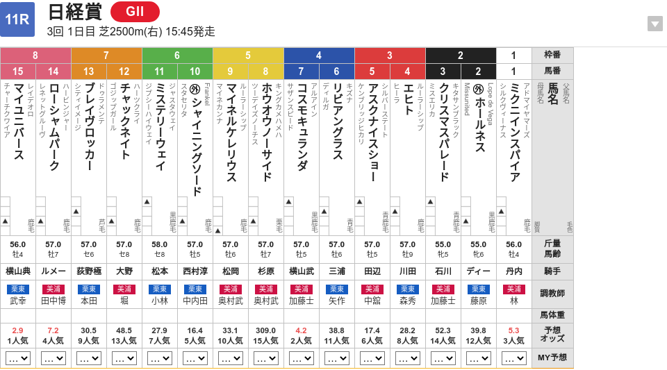

### 【毎日杯 2026/03/28(土) 】

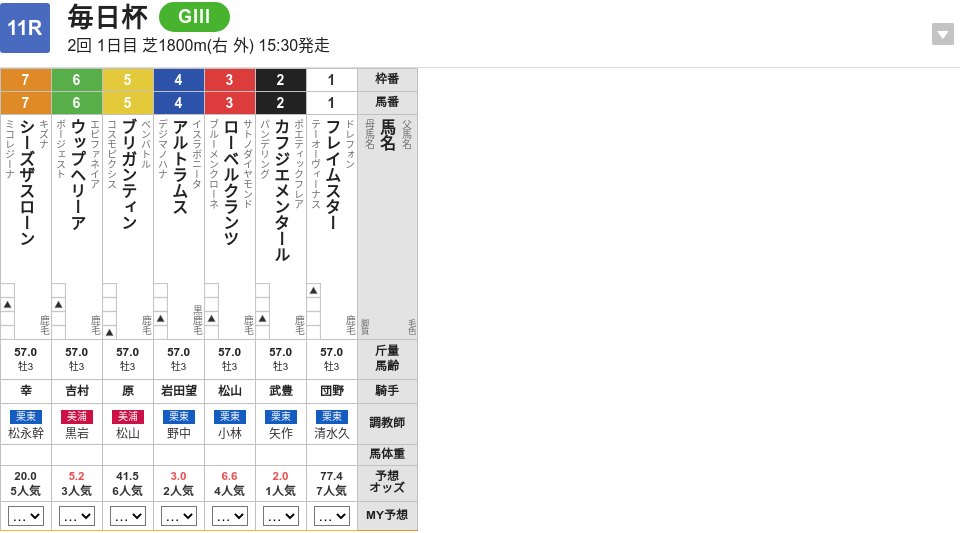

### 【マーチステークス 2026/03/29(日) 】

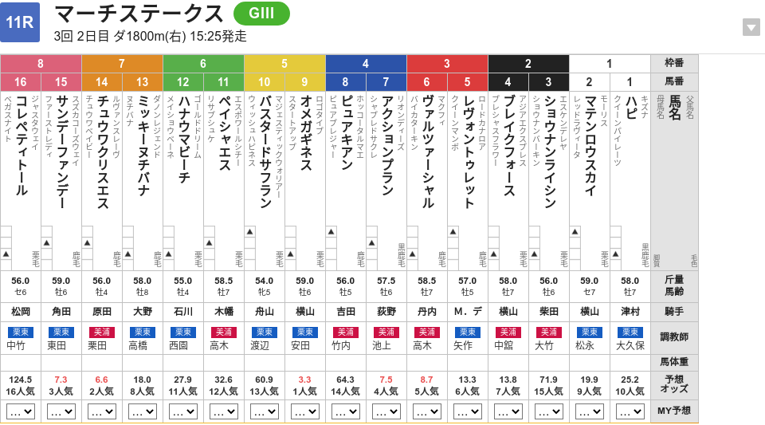

### 【高松宮記念 2026/03/29(日) 】

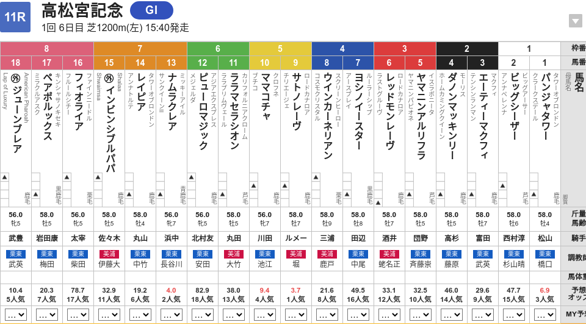

## 4. 単勝予測結果

### 【日経賞(GⅡ) 2026/03/28(土)】

| 枠番 | 馬番 | 人気 | オッズ | 馬名 | 騎手 | 調教師 | 予測タイム(sec) | 1_順位 | 1-3着内確率(%) | 2_順位 | ﾀﾞｰｸﾎｰｽ確率(%) | 3_順位 |
| --- | --- | --- | --- | --- | --- | --- | --- | --- | --- | --- | --- | --- |
| 1 | 1 | 3 | 5.3 | ミクニインスパイア | 丹内祐次 | 林徹 | 161.9 | 13 | 23.1 | 2 | 0.5 | 14 |
| 2 | 2 | 12 | 39.8 | ホールネス | Ｍ．ディー | 藤原英昭 | 161.5 | 12 | 10.3 | 10 | 64.7 | 3 |
| 2 | 3 | 14 | 52.3 | クリスマスパレード | 石川裕紀人 | 加藤士津八 | 160.5 | 4 | 21.0 | 3 | 69.9 | 1 |
| 3 | 4 | 8 | 28.2 | エヒト | 川田将雅 | 森秀行 | 162.1 | 14 | 10.8 | 9 | 0.9 | 11 |
| 3 | 5 | 6 | 17.4 | アスクナイスショー | 田辺裕信 | 中舘英二 | 161.3 | 10 | 17.8 | 5 | 1.1 | 8 |
| 4 | 6 | 11 | 38.8 | リビアングラス | 三浦皇成 | 矢作芳人 | 161.1 | 9 | 9.2 | 11 | 55.0 | 4 |
| 4 | 7 | 2 | 4.2 | コスモキュランダ | 横山武史 | 加藤士津八 | 160.9 | 7 | 20.3 | 4 | 0.4 | 15 |
| 5 | 8 | 15 | 309.0 | ホウオウノーサイド | 杉原誠人 | 奥村武 | 161.0 | 8 | 4.3 | 15 | 19.0 | 7 |
| 5 | 9 | 10 | 33.1 | マイネルケレリウス | 松岡正海 | 奥村武 | 160.2 | 3 | 13.7 | 6 | 53.3 | 5 |
| 6 | 10 | 5 | 16.4 | シャイニングソード | 西村淳也 | 中内田充正 | 161.4 | 11 | 13.3 | 7 | 1.0 | 10 |

[output cut: 5 more lines]

### 【毎日杯(GⅢ) 2026/03/28(土)】

| 枠番 | 馬番 | 人気 | オッズ | 馬名 | 騎手 | 調教師 | 予測タイム(sec) | 1_順位 | 1-3着内確率(%) | 2_順位 | ﾀﾞｰｸﾎｰｽ確率(%) | 3_順位 |
| --- | --- | --- | --- | --- | --- | --- | --- | --- | --- | --- | --- | --- |
| 1 | 1 | 7 | 77.4 | フレイムスター | 団野大成 | 清水久詞 | 120.1 | 5 | 3.7 | 5 | 11.4 | 2 |
| 2 | 2 | 1 | 2.0 | カフジエメンタール | 武豊 | 矢作芳人 | 106.2 | 1 | 21.1 | 3 | 0.4 | 6 |
| 3 | 3 | 4 | 6.6 | ローベルクランツ | 松山弘平 | 小林真也 | 113.6 | 3 | 19.6 | 4 | 1.4 | 4 |
| 4 | 4 | 2 | 3.0 | アルトラムス | 岩田望来 | 野中賢二 | 110.6 | 2 | 35.1 | 1 | 0.4 | 7 |
| 5 | 5 | 6 | 41.5 | ブリガンティン | 原優介 | 松山将樹 | 120.9 | 6 | 2.8 | 7 | 9.8 | 3 |
| 6 | 6 | 3 | 5.2 | ウップヘリーア | 吉村誠之助 | 黒岩陽一 | 116.5 | 4 | 22.2 | 2 | 1.0 | 5 |
| 7 | 7 | 5 | 20.0 | シーズザスローン | 幸英明 | 松永幹夫 | 121.4 | 7 | 3.2 | 6 | 25.5 | 1 |

## 5. 人気と着順の乖離率推移

### 【日経賞_1990y_2019y】

[interactive chart not shown]

### 【毎日杯_1990y_2019y】

[interactive chart not shown]

### 【マーチステークス_1994y_2019y】

[interactive chart not shown]

### 【高松宮記念_1998y_2019y】

[interactive chart not shown]

### 【日経賞_1990y_2019y】

| No | 開催年 | 不整合率(%) | 頭数 | 人気別着順(1-3位) | 人気別着順(全体) |
| --- | --- | --- | --- | --- | --- |
| 30 | 2019 | 37.5 | 12頭 | 3-1-4 | 3\|1\|4\|10\|6\|2\|5\|7\|9\|8\|12\|11 |
| 29 | 2018 | 62.6 | 15頭 | 3-7-6 | 3\|7\|6\|4\|2\|5\|8\|9\|1\|12\|13\|10\|11\|14\|15 |
| 28 | 2017 | 42.2 | 16頭 | 4-7-6 | 4\|7\|6\|2\|1\|3\|10\|12\|5\|9\|8\|11\|14\|15\|16\|13 |
| 27 | 2016 | 22.7 | 9頭 | 2-1-4 | 2\|1\|4\|3\|5\|9\|6\|8\|7 |
| 26 | 2015 | 38.4 | 12頭 | 4-5-6 | 4\|5\|6\|1\|7\|9\|8\|2\|10\|3\|12\|11 |
| 25 | 2014 | 24.5 | 15頭 | 1-10-3 | 1\|10\|3\|13\|2\|11\|15\|6\|14\|4\|9\|5\|8\|7\|12 |
| 24 | 2013 | 34.2 | 14頭 | 1-9-7 | 1\|9\|7\|3\|11\|4\|6\|10\|2\|13\|5\|12\|14\|8 |
| 23 | 2012 | 30.8 | 14頭 | 12-2-1 | 12\|2\|1\|6\|9\|10\|8\|3\|5\|14\|4\|11\|13\|7 |
| 22 | 2011 | 13.0 | 10頭 | 1-2-3 | 1\|2\|3\|6\|8\|9\|7\|10\|5\|4 |
| 21 | 2010 | 49.5 | 15頭 | 6-4-7 | 6\|4\|7\|2\|5\|11\|1\|3\|10\|9\|8\|14\|12\|13\|15 |

[output cut: 20 more lines]

### 【毎日杯_1990y_2019y】

| No | 開催年 | 不整合率(%) | 頭数 | 人気別着順(1-3位) | 人気別着順(全体) |
| --- | --- | --- | --- | --- | --- |
| 29 | 2019 | 43.4 | 13頭 | 3-2-1 | 3\|2\|1\|7\|4\|8\|11\|5\|9\|6\|13\|10\|12 |
| 28 | 2018 | 7.7 | 10頭 | 1-2-3 | 1\|2\|3\|8\|9\|5\|4\|6\|10\|7 |
| 27 | 2017 | 37.3 | 8頭 | 2-1-7 | 2\|1\|7\|5\|6\|4\|3\|8 |
| 26 | 2016 | 17.1 | 10頭 | 1-4-2 | 1\|4\|2\|6\|3\|5\|8\|7\|9\|10 |
| 25 | 2015 | 53.2 | 15頭 | 7-3-1 | 7\|3\|1\|6\|8\|5\|13\|12\|9\|10\|14\|4\|15\|11\|2 |
| 24 | 2014 | 50.2 | 14頭 | 5-3-4 | 5\|3\|4\|1\|2\|8\|10\|11\|6\|13\|7\|12\|9\|14 |
| 23 | 2013 | 28.8 | 13頭 | 1-6-3 | 1\|6\|3\|9\|2\|5\|13\|8\|10\|11\|4\|12\|7 |
| 22 | 2012 | 31.5 | 13頭 | 1-3-7 | 1\|3\|7\|8\|11\|2\|10\|6\|12\|9\|5\|4\|13 |
| 21 | 2010 | 59.3 | 10頭 | 3-5-2 | 3\|5\|2\|9\|1\|7\|6\|8\|10\|11 |
| 20 | 2009 | 11.5 | 14頭 | 1-12-2 | 1\|12\|2\|3\|5\|7\|6\|11\|8\|4\|13\|10\|14\|9 |

[output cut: 19 more lines]

### 【マーチステークス_1994y_2019y】

| No | 開催年 | 不整合率(%) | 頭数 | 人気別着順(1-3位) | 人気別着順(全体) |
| --- | --- | --- | --- | --- | --- |
| 26 | 2019 | 47.7 | 16頭 | 8-11-12 | 8\|11\|12\|2\|16\|3\|9\|6\|10\|1\|13\|5\|15\|7\|14\|4 |
| 25 | 2018 | 47.4 | 16頭 | 2-5-10 | 2\|5\|10\|6\|8\|7\|4\|9\|1\|13\|12\|15\|14\|3\|16\|11 |
| 24 | 2017 | 44.0 | 16頭 | 10-2-11 | 10\|2\|11\|3\|4\|7\|5\|9\|15\|12\|13\|1\|8\|14\|16\|6 |
| 23 | 2016 | 14.6 | 15頭 | 8-1-2 | 8\|1\|2\|3\|5\|12\|15\|11\|6\|13\|4\|9\|7\|10\|14 |
| 22 | 2015 | 47.4 | 16頭 | 6-5-1 | 6\|5\|1\|4\|3\|12\|13\|2\|9\|11\|15\|8\|10\|14\|7\|16 |
| 21 | 2014 | 50.8 | 16頭 | 3-2-5 | 3\|2\|5\|1\|9\|12\|14\|8\|7\|6\|11\|16\|13\|4\|15\|10 |
| 20 | 2013 | 45.4 | 16頭 | 2-6-3 | 2\|6\|3\|5\|4\|11\|12\|7\|10\|1\|13\|8\|16\|9\|15\|14 |
| 19 | 2012 | 51.7 | 16頭 | 6-16-7 | 6\|16\|7\|8\|4\|1\|14\|12\|3\|5\|9\|13\|2\|10\|15\|11 |
| 18 | 2011 | 35.8 | 16頭 | 7-9-6 | 7\|9\|6\|2\|1\|13\|12\|3\|10\|4\|11\|16\|14\|5\|8\|15 |
| 17 | 2010 | 53.6 | 16頭 | 4-6-3 | 4\|6\|3\|1\|14\|5\|8\|10\|16\|11\|9\|2\|12\|15\|7\|13 |

[output cut: 16 more lines]

### 【高松宮記念_1998y_2019y】

| No | 開催年 | 不整合率(%) | 頭数 | 人気別着順(1-3位) | 人気別着順(全体) |
| --- | --- | --- | --- | --- | --- |
| 22 | 2019 | 45.8 | 18頭 | 3-12-17 | 3\|12\|17\|1\|11\|5\|8\|4\|7\|16\|14\|15\|18\|6\|2\|9\|10\|13 |
| 21 | 2018 | 38.6 | 18頭 | 2-3-10 | 2\|3\|10\|4\|6\|5\|7\|1\|15\|12\|9\|8\|17\|13\|16\|18\|14\|11 |
| 20 | 2017 | 36.3 | 18頭 | 5-2-1 | 5\|2\|1\|16\|7\|10\|11\|12\|6\|3\|9\|17\|14\|13\|4\|8\|18\|15 |
| 19 | 2016 | 11.3 | 18頭 | 1-2-3 | 1\|2\|3\|16\|5\|14\|6\|10\|4\|17\|7\|15\|12\|11\|18\|9\|13\|8 |
| 18 | 2015 | 66.3 | 18頭 | 4-6-3 | 4\|6\|3\|10\|5\|2\|15\|12\|13\|14\|17\|16\|1\|8\|11\|7\|9\|18 |
| 17 | 2014 | 38.7 | 18頭 | 3-8-1 | 3\|8\|1\|15\|2\|16\|5\|11\|7\|14\|13\|17\|6\|9\|4\|12\|18\|10 |
| 16 | 2013 | 18.2 | 17頭 | 1-2-10 | 1\|2\|10\|4\|6\|7\|9\|14\|3\|16\|15\|8\|11\|5\|12\|13\|17 |
| 15 | 2012 | 33.1 | 18頭 | 2-3-1 | 2\|3\|1\|6\|5\|9\|7\|13\|10\|18\|4\|16\|11\|17\|12\|15\|8\|14 |
| 14 | 2011 | 53.5 | 15頭 | 3-4-11 | 3\|4\|11\|10\|5\|13\|8\|15\|6\|1\|2\|14\|12\|9\|7 |
| 13 | 2010 | 30.6 | 18頭 | 1-6-3 | 1\|6\|3\|4\|2\|15\|11\|8\|13\|10\|17\|14\|5\|16\|12\|9\|18\|7 |

[output cut: 12 more lines]

## 6. 1-3番人気馬の着順分類予測

### 【日経賞】

| 分類 | 凡例 | 発生確率(%) | 当該レース | 当該レースランク | 直近1年間 |
| --- | --- | --- | --- | --- | --- |
| 1: 1番人気のみ (1_pop1) | 1 \| * \| * | 17.9 | 1.07 | 1.07 | 0.00 |
| 5: 1,3番人気のみ (5_pop13) | 1 \| 3 \| * | 17.6 | 0.58 | 0.58 | 0.70 |
| 4: 1,2番人気のみ (4_pop12) | 1 \| 2 \| * | 16.4 | 0.98 | 0.98 | 0.00 |
| 8: 1,2,3番人気すべて着外 (8_darkhorse) | * \| * \| * | 13.1 | 1.58 | 1.58 | 0.52 |
| 2: 2番人気のみ (2_pop2) | 2 \| * \| * | 9.9 | 1.77 | 1.77 | 0.00 |
| 3: 3番人気のみ (3_pop3) | 3 \| * \| * | 8.9 | 1.07 | 1.07 | 0.36 |
| 6: 2,3番人気のみ (6_pop23) | 2 \| 3 \| * | 8.7 | 3.11 | 3.11 | 0.00 |
| 7: 1,2,3番人気すべて着内 (7_pop123) | 1 \| 2 \| 3 | 7.5 | 0.68 | 0.68 | 0.30 |

### 【毎日杯】

| 分類 | 凡例 | 発生確率(%) | 当該レース | 当該レースランク | 直近1年間 |
| --- | --- | --- | --- | --- | --- |
| 1: 1番人気のみ (1_pop1) | 1 \| * \| * | 17.4 | 1.53 | 1.30 | 0.00 |
| 4: 1,2番人気のみ (4_pop12) | 1 \| 2 \| * | 16.5 | 0.64 | 0.92 | 0.00 |
| 8: 1,2,3番人気すべて着外 (8_darkhorse) | * \| * \| * | 14.4 | 4.97 | 0.60 | 0.58 |
| 5: 1,3番人気のみ (5_pop13) | 1 \| 3 \| * | 13.3 | 1.17 | 2.22 | 0.53 |
| 7: 1,2,3番人気すべて着内 (7_pop123) | 1 \| 2 \| 3 | 10.3 | 0.36 | 0.69 | 0.41 |
| 2: 2番人気のみ (2_pop2) | 2 \| * \| * | 10.0 | 0.00 | 1.33 | 0.00 |
| 6: 2,3番人気のみ (6_pop23) | 2 \| 3 \| * | 9.4 | 1.09 | 1.25 | 0.00 |
| 3: 3番人気のみ (3_pop3) | 3 \| * \| * | 8.6 | 0.75 | 0.96 | 0.34 |

### 【マーチステークス】

| 分類 | 凡例 | 発生確率(%) | 当該レース | 当該レースランク | 直近1年間 |
| --- | --- | --- | --- | --- | --- |
| 8: 1,2,3番人気すべて着外 (8_darkhorse) | * \| * \| * | 18.6 | 0.40 | 0.78 | 0.74 |
| 1: 1番人気のみ (1_pop1) | 1 \| * \| * | 17.2 | 1.10 | 1.28 | 0.00 |
| 4: 1,2番人気のみ (4_pop12) | 1 \| 2 \| * | 16.3 | 1.73 | 0.91 | 0.00 |
| 5: 1,3番人気のみ (5_pop13) | 1 \| 3 \| * | 13.2 | 0.00 | 2.20 | 0.53 |
| 2: 2番人気のみ (2_pop2) | 2 \| * \| * | 9.9 | 0.63 | 1.32 | 0.00 |
| 6: 2,3番人気のみ (6_pop23) | 2 \| 3 \| * | 9.3 | 1.50 | 1.24 | 0.00 |
| 3: 3番人気のみ (3_pop3) | 3 \| * \| * | 8.5 | 1.37 | 0.94 | 0.34 |
| 7: 1,2,3番人気すべて着内 (7_pop123) | 1 \| 2 \| 3 | 6.9 | 0.00 | 0.46 | 0.28 |

### 【高松宮記念】

| 分類 | 凡例 | 発生確率(%) | 当該レース | 当該レースランク | 直近1年間 |
| --- | --- | --- | --- | --- | --- |
| 5: 1,3番人気のみ (5_pop13) | 1 \| 3 \| * | 15.8 | 1.10 | 1.10 | 0.63 |
| 4: 1,2番人気のみ (4_pop12) | 1 \| 2 \| * | 15.7 | 1.10 | 1.10 | 0.00 |
| 1: 1番人気のみ (1_pop1) | 1 \| * \| * | 15.1 | 1.41 | 1.41 | 0.00 |
| 3: 3番人気のみ (3_pop3) | 3 \| * \| * | 14.5 | 0.45 | 0.45 | 0.58 |
| 8: 1,2,3番人気すべて着外 (8_darkhorse) | * \| * \| * | 12.0 | 0.00 | 0.00 | 0.48 |
| 2: 2番人気のみ (2_pop2) | 2 \| * \| * | 10.2 | 1.44 | 1.44 | 0.00 |
| 6: 2,3番人気のみ (6_pop23) | 2 \| 3 \| * | 9.0 | 0.63 | 0.63 | 0.00 |
| 7: 1,2,3番人気すべて着内 (7_pop123) | 1 \| 2 \| 3 | 7.8 | 1.10 | 1.10 | 0.31 |

## 7. 3連複予測結果

### 【日経賞(GⅡ) 2026/03/28(土)】

| 分類 | 馬番 | 枠番 | 人気 | 平均予測タイム(sec) | 1-3着内確率(%) | ﾀﾞｰｸﾎｰｽ確率(%) | 馬名 | 騎手 | 調教師 |
| --- | --- | --- | --- | --- | --- | --- | --- | --- | --- |
| 3: 3番人気のみ (3_pop3) | 1-14-3 | 1-8-2 | 3-4-14 | 158.70 | 2.05 | 0.00 | ミクニインスパイア \| ローシャムパーク \| クリスマスパレード | 丹内祐次 \| Ｃ．ルメール \| 石川裕紀人 | 林徹 \| 田中博康 \| 加藤士津八 |
| 6: 2,3番人気のみ (6_pop23) | 7-1-14 | 4-1-8 | 2-3-4 | 158.83 | 1.99 | 0.00 | コスモキュランダ \| ミクニインスパイア \| ローシャムパーク | 横山武史 \| 丹内祐次 \| Ｃ．ルメール | 加藤士津八 \| 林徹 \| 田中博康 |
| 2: 2番人気のみ (2_pop2) | 7-14-3 | 4-8-2 | 2-4-14 | 158.37 | 1.80 | 0.00 | コスモキュランダ \| ローシャムパーク \| クリスマスパレード | 横山武史 \| Ｃ．ルメール \| 石川裕紀人 | 加藤士津八 \| 田中博康 \| 加藤士津八 |
| 3: 3番人気のみ (3_pop3) | 1-14-5 | 1-8-3 | 3-4-6 | 158.97 | 1.74 | 0.00 | ミクニインスパイア \| ローシャムパーク \| アスクナイスショー | 丹内祐次 \| Ｃ．ルメール \| 田辺裕信 | 林徹 \| 田中博康 \| 中舘英二 |
| 8: 1,2,3番人気すべて着外 (8_darkhorse) | 14-5-3 | 8-3-2 | 4-6-14 | 158.50 | 1.58 | 0.00 | ローシャムパーク \| アスクナイスショー \| クリスマスパレード | Ｃ．ルメール \| 田辺裕信 \| 石川裕紀人 | 田中博康 \| 中舘英二 \| 加藤士津八 |
| 2: 2番人気のみ (2_pop2) | 7-14-5 | 4-8-3 | 2-4-6 | 158.63 | 1.53 | 0.00 | コスモキュランダ \| ローシャムパーク \| アスクナイスショー | 横山武史 \| Ｃ．ルメール \| 田辺裕信 | 加藤士津八 \| 田中博康 \| 中舘英二 |
| 3: 3番人気のみ (3_pop3) | 1-14-9 | 1-8-5 | 3-4-10 | 158.60 | 1.34 | 0.00 | ミクニインスパイア \| ローシャムパーク \| マイネルケレリウス | 丹内祐次 \| Ｃ．ルメール \| 松岡正海 | 林徹 \| 田中博康 \| 奥村武 |
| 3: 3番人気のみ (3_pop3) | 1-14-10 | 1-8-6 | 3-4-5 | 159.00 | 1.30 | 0.00 | ミクニインスパイア \| ローシャムパーク \| シャイニングソード | 丹内祐次 \| Ｃ．ルメール \| 西村淳也 | 林徹 \| 田中博康 \| 中内田充正 |
| 8: 1,2,3番人気すべて着外 (8_darkhorse) | 14-9-3 | 8-5-2 | 4-10-14 | 158.13 | 1.22 | 0.19 | ローシャムパーク \| マイネルケレリウス \| クリスマスパレード | Ｃ．ルメール \| 松岡正海 \| 石川裕紀人 | 田中博康 \| 奥村武 \| 加藤士津八 |
| 5: 1,3番人気のみ (5_pop13) | 15-1-14 | 8-1-8 | 1-3-4 | 153.67 | 1.20 | 0.00 | マイユニバース \| ミクニインスパイア \| ローシャムパーク | 横山典弘 \| 丹内祐次 \| Ｃ．ルメール | 武幸四郎 \| 林徹 \| 田中博康 |

[output cut: 445 more lines]

### 【毎日杯(GⅢ) 2026/03/28(土)】

| 分類 | 馬番 | 枠番 | 人気 | 平均予測タイム(sec) | 1-3着内確率(%) | ﾀﾞｰｸﾎｰｽ確率(%) | 馬名 | 騎手 | 調教師 |
| --- | --- | --- | --- | --- | --- | --- | --- | --- | --- |
| 7: 1,2,3番人気すべて着内 (7_pop123) | 2-4-6 | 2-4-6 | 1-2-3 | 111.10 | 1.64 | 0.00 | カフジエメンタール \| アルトラムス \| ウップヘリーア | 武豊 \| 岩田望来 \| 吉村誠之助 | 矢作芳人 \| 野中賢二 \| 黒岩陽一 |
| 6: 2,3番人気のみ (6_pop23) | 4-6-3 | 4-6-3 | 2-3-4 | 113.57 | 1.53 | 0.00 | アルトラムス \| ウップヘリーア \| ローベルクランツ | 岩田望来 \| 吉村誠之助 \| 松山弘平 | 野中賢二 \| 黒岩陽一 \| 小林真也 |
| 4: 1,2番人気のみ (4_pop12) | 2-4-3 | 2-4-3 | 1-2-4 | 110.13 | 1.45 | 0.00 | カフジエメンタール \| アルトラムス \| ローベルクランツ | 武豊 \| 岩田望来 \| 松山弘平 | 矢作芳人 \| 野中賢二 \| 小林真也 |
| 5: 1,3番人気のみ (5_pop13) | 2-6-3 | 2-6-3 | 1-3-4 | 112.10 | 0.92 | 0.00 | カフジエメンタール \| ウップヘリーア \| ローベルクランツ | 武豊 \| 吉村誠之助 \| 松山弘平 | 矢作芳人 \| 黒岩陽一 \| 小林真也 |
| 6: 2,3番人気のみ (6_pop23) | 4-6-1 | 4-6-1 | 2-3-7 | 115.73 | 0.29 | 0.00 | アルトラムス \| ウップヘリーア \| フレイムスター | 岩田望来 \| 吉村誠之助 \| 団野大成 | 野中賢二 \| 黒岩陽一 \| 清水久詞 |
| 4: 1,2番人気のみ (4_pop12) | 2-4-1 | 2-4-1 | 1-2-7 | 112.30 | 0.27 | 0.00 | カフジエメンタール \| アルトラムス \| フレイムスター | 武豊 \| 岩田望来 \| 団野大成 | 矢作芳人 \| 野中賢二 \| 清水久詞 |
| 2: 2番人気のみ (2_pop2) | 4-3-1 | 4-3-1 | 2-4-7 | 114.77 | 0.25 | 0.00 | アルトラムス \| ローベルクランツ \| フレイムスター | 岩田望来 \| 松山弘平 \| 団野大成 | 野中賢二 \| 小林真也 \| 清水久詞 |
| 6: 2,3番人気のみ (6_pop23) | 4-6-7 | 4-6-7 | 2-3-5 | 116.17 | 0.25 | 0.00 | アルトラムス \| ウップヘリーア \| シーズザスローン | 岩田望来 \| 吉村誠之助 \| 幸英明 | 野中賢二 \| 黒岩陽一 \| 松永幹夫 |
| 4: 1,2番人気のみ (4_pop12) | 2-4-7 | 2-4-7 | 1-2-5 | 112.73 | 0.23 | 0.00 | カフジエメンタール \| アルトラムス \| シーズザスローン | 武豊 \| 岩田望来 \| 幸英明 | 矢作芳人 \| 野中賢二 \| 松永幹夫 |
| 6: 2,3番人気のみ (6_pop23) | 4-6-5 | 4-6-5 | 2-3-6 | 116.00 | 0.22 | 0.00 | アルトラムス \| ウップヘリーア \| ブリガンティン | 岩田望来 \| 吉村誠之助 \| 原優介 | 野中賢二 \| 黒岩陽一 \| 松山将樹 |

[output cut: 25 more lines]

## 8. 直近の全レース情報

| No | 日付 | 競馬場 | R | 発走 | レース名 | 距離 | 頭数 | URL(netkeiba) |
| --- | --- | --- | --- | --- | --- | --- | --- | --- |
| 1 | 2026/03/28(土) | 06_中山 | 9R | 14:35 | ブラッドスト | 0 | 26頭 | https://race.netkeiba.com/race/shutuba.html?race_id=202606030109&amp;rf=race_list |
| 2 | 2026/03/28(土) | 06_中山 | 10R | 15:10 | 伏竜S | 0 | 14頭 | https://race.netkeiba.com/race/shutuba.html?race_id=202606030110&amp;rf=race_list |
| 3 | 2026/03/28(土) | 06_中山 | 11R | 15:45 | 日経賞 | 0 | 16頭 | https://race.netkeiba.com/race/shutuba.html?race_id=202606030111&amp;rf=race_list |
| 4 | 2026/03/28(土) | 09_阪神 | 8R | 13:45 | 三木ホースJ | 0 | 12頭 | https://race.netkeiba.com/race/shutuba.html?race_id=202609020108&amp;rf=race_list |
| 5 | 2026/03/28(土) | 09_阪神 | 9R | 14:20 | 君子蘭賞 | 0 | 8頭 | https://race.netkeiba.com/race/shutuba.html?race_id=202609020109&amp;rf=race_list |
| 6 | 2026/03/28(土) | 09_阪神 | 10R | 14:55 | 仲春特別 | 0 | 22頭 | https://race.netkeiba.com/race/shutuba.html?race_id=202609020110&amp;rf=race_list |
| 7 | 2026/03/28(土) | 09_阪神 | 11R | 15:30 | 毎日杯 | 0 | 10頭 | https://race.netkeiba.com/race/shutuba.html?race_id=202609020111&amp;rf=race_list |
| 8 | 2026/03/28(土) | 07_中京 | 9R | 14:10 | ロイヤルBS | 0 | 18頭 | https://race.netkeiba.com/race/shutuba.html?race_id=202607010509&amp;rf=race_list |
| 9 | 2026/03/28(土) | 07_中京 | 10R | 14:45 | インディア賞 | 0 | 14頭 | https://race.netkeiba.com/race/shutuba.html?race_id=202607010510&amp;rf=race_list |
| 10 | 2026/03/28(土) | 07_中京 | 11R | 15:20 | マレーシアC | 0 | 19頭 | https://race.netkeiba.com/race/shutuba.html?race_id=202607010511&amp;rf=race_list |

[output cut: 11 more lines]